# Cross-Validation

## Where we left off

- **Day 13 activity:** we chose \(K\) in KNN by its error on **one** test set.
  - 500 colleges to train, 277 to test.
  - But why split at all, and does the split matter?
- **Today: cross-validation (CV)**, on a new example: a bank’s 10,000 credit card customers. Who will default?
  - Why one split is a noisy ruler
  - 5-fold CV: every case gets a turn in the test set
  - Reading a CV table: the mean, the SD across folds, and the SE

## Why split the data at all?

> **A new customer applies for a credit card. How can we tell whether KNN is a good model before we learn if they default? And how should we pick \(K\)?**
- **Real predictions can’t be graded yet.** We won’t know for months whether this customer defaults.
- **Pick the \(K\) with the lowest error on past customers?** \(K = 1\) always wins: every past customer is their own nearest neighbor, so training error is 0%.
  - Not a great model, just way overfitting: it memorized the 10,000 customers.
- **So hold some past customers out** and pretend they’re new.

## How should we split the data?

> **We have 10,000 past customers, and we know who defaulted. How many go to training, and how many to testing? And which ones?**
- **Training set:** the model learns from these.
- **Test set:** hide their answers, predict them, then compare with the truth.
- **A tradeoff:**
  - More in training: a better model.
  - More in testing: a steadier grade.
- **Which ones?** Pick them **at random**, so the test set isn’t biased (e.g., not just the customers with the biggest balances).
- **Say, half and half:** 5,000 each. Does the luck of the split matter?

## One split, five answers

> **Same customers, same KNN, a different random split. What’s the best \(K\)?**

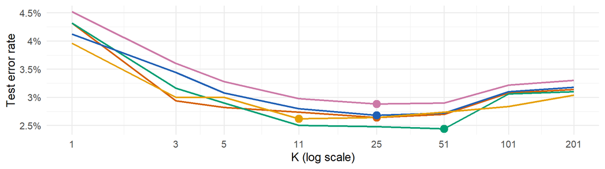

- Each color: one random split. Big dot: that split’s best \(K\) (25, 51, 25, 25, 11).
- Only about 158 test customers default: which ones land in the test set moves the error.

## Two problems with one split

- **Noisy.** The answer depends on which customers happen to land in the test set.
  - A different seed gives a different “best” \(K\) and a different error rate.
- **Wasteful.** 5,000 of 10,000 customers (50%) never help train the model.
  - Less training data makes every fit noisier.

**Cross-validation fixes both:** split several ways, and let every customer take a turn as test data.

## 5-fold cross-validation

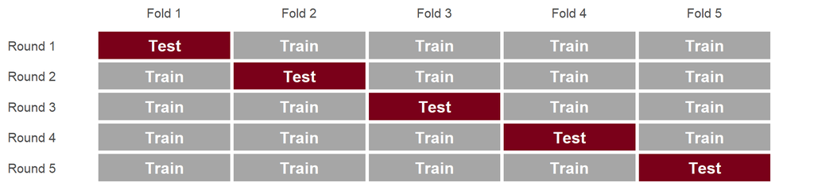

1. Randomly split the data into 5 **folds** (2,000 customers each).
2. Train on 4 folds, test on the 5th. Repeat 5 times, so each fold is tested once.
3. **CV error** = the average of the 5 test errors.

## One K, five folds

> **KNN with \(K = 11\). How much do the 5 test errors disagree?**

|  | Fold 1 | Fold 2 | Fold 3 | Fold 4 | Fold 5 | Mean | SD | SE |
| --- | --- | --- | --- | --- | --- | --- | --- | --- |
| **Test error** | 2.70% | 2.75% | 3.05% | 2.55% | 2.55% | **2.72%** | **0.20%** | **0.09%** |

- **Mean:** the CV estimate of test error. It uses every customer as test data once.
- **SD across folds:** how much a single test set’s answer bounces around. One train/test split is like looking at just one fold.
- **SE = SD / \(\sqrt{5}\):** how much the **mean** bounces around. An average of 5 folds is steadier than any one fold. Use the SE to compare CV errors.

## Choosing K with cross-validation

> **Which \(K\) has the lowest CV error, and is it really better than its neighbors?**

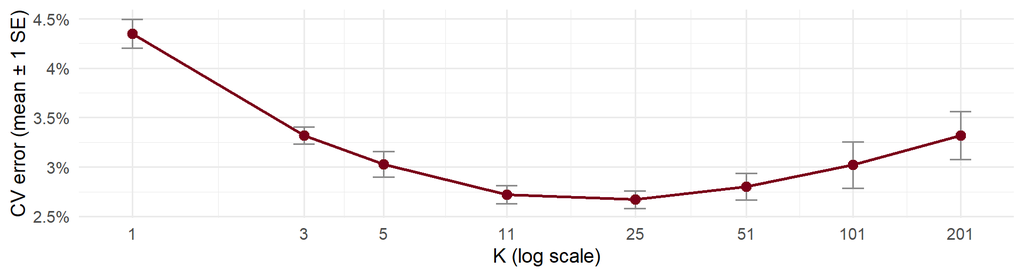

- Lowest: \(K =\) 25 at 2.67%. Only \(K\) from 11 to 25 are within one SE of it.
- Differences smaller than one SE are noise: any of those \(K\) is a fine choice. One split’s “best” ranged from 11 to 51; CV narrows it down.

## KNN or logistic regression, fairly

> **Both scored with the same 5 folds. Is one really better?**

| Model | Mean CV error | SD across folds | SE |
| --- | --- | --- | --- |
| Logistic regression | 2.65% | 0.19% | 0.08% |
| KNN, K = 11 | 2.72% | 0.20% | 0.09% |
| KNN, K = 25 (lowest CV error) | 2.67% | 0.20% | 0.09% |

- The gaps (at most 0.07 points) are smaller than one SE (about 0.08 points): a tie.
- In a tie, prefer logistic regression: more stable, and it explains itself (Day 13).

## How many folds?

- **5 or 10** is standard.
  - More folds: each round trains on more data, but there are more rounds to run.
  - **Leave-one-out (LOOCV):** \(n\) folds of one case each. The most training data, the most computing.
- Don’t mix up the two letters: \(k\) **folds** in CV vs \(K\) **neighbors** in KNN.
- CV **chooses** (the method, \(K\), the predictors). Then refit the winner on **all** the data to make real predictions.

## Summary

**Cross-validation** estimates test error without trusting one lucky (or unlucky) split.

- One train/test split is **noisy** (the answer depends on the seed) and **wasteful** (the test cases never train the model).
- **5-fold CV:** each fold is the test set once; the CV error is the average of the 5 test errors.
- Report the **mean** and the **SE** (= SD across folds / \(\sqrt{5}\)). Treat differences smaller than one SE as a tie.
- In a tie, pick the simpler, more stable, more interpretable model.

## For rest of class

- Work on the `day14_activity`
  - back to the colleges: one split says \(K = 1\) wins. Does 5-fold CV agree? And does the best KNN beat your logistic regression by more than one SE?
- Ask me questions if you run into issues